# exercise-11

2024-03-25

# Practice ANOVA

## Preliminaries

```r
library(tidyverse)
```

```r
library(dplyr)
library(mosaic)
library(readr)
library(skimr)
library(broom)
library(car)
library(manipulate)
library(ggplot2)
library(infer)
#Load "AVONETdataset1.csv" dataset as a tibble
f <- "https://raw.githubusercontent.com/difiore/ada-2024-datasets/main/AVONETdataset1.csv"
(d <- read_csv(f,col_names = TRUE))
```

```
## # A tibble: 11,009 × 37
##    Sequence Species1   Family1 Order1 Avibase.ID1 Total.individuals Female  Male
##       <dbl> <chr>      <chr>   <chr>  <chr>                   <dbl>  <dbl> <dbl>
##  1     3103 Accipiter… Accipi… Accip… AVIBASE-BB…                 5      2     0
##  2     3090 Accipiter… Accipi… Accip… AVIBASE-1A…                10      4     6
##  3     3125 Accipiter… Accipi… Accip… AVIBASE-AD…                11      4     5
##  4     3116 Accipiter… Accipi… Accip… AVIBASE-68…                 4      4     0
##  5     3092 Accipiter… Accipi… Accip… AVIBASE-84…                 8      4     4
##  6     3091 Accipiter… Accipi… Accip… AVIBASE-6B…                 1      0     1
##  7     3089 Accipiter… Accipi… Accip… AVIBASE-9D…                 6      2     2
##  8     3115 Accipiter… Accipi… Accip… AVIBASE-21…                 5      2     3
##  9     3130 Accipiter… Accipi… Accip… AVIBASE-32…                 7      1     5
## 10     3123 Accipiter… Accipi… Accip… AVIBASE-EB…                 5      2     3
## # ℹ 10,999 more rows
## # ℹ 29 more variables: Unknown <dbl>, Complete.measures <dbl>,
## #   Beak.Length_Culmen <dbl>, Beak.Length_Nares <dbl>, Beak.Width <dbl>,
## #   Beak.Depth <dbl>, Tarsus.Length <dbl>, Wing.Length <dbl>,
## #   Kipps.Distance <dbl>, Secondary1 <dbl>, `Hand-Wing.Index` <dbl>,
## #   Tail.Length <dbl>, Mass <dbl>, Mass.Source <chr>, Mass.Refs.Other <chr>,
## #   Inference <chr>, Traits.inferred <chr>, Reference.species <chr>, …
```

```r
#Winnow the dataset to include only the following variables: Species1, Family1, Order1, Beak.Length_Culmen, Beak.Width, Beak.Depth, Tarsus.Length, Wing.Length, Tail.Length, Mass, Habitat, Migration, Trophic.Level, Trophic.Niche, Min.Latitude, Max.Latitude, Centroid.Latitude, Primary.Lifestyle, and Range.Size

(d <- d |> select("Species1","Family1","Order1","Beak.Length_Culmen","Beak.Width","Beak.Depth","Tarsus.Length","Wing.Length","Tail.Length","Mass","Habitat","Migration","Trophic.Level","Trophic.Niche","Min.Latitude","Max.Latitude","Centroid.Latitude","Primary.Lifestyle","Range.Size"))
```

```
## # A tibble: 11,009 × 19
##    Species1              Family1 Order1 Beak.Length_Culmen Beak.Width Beak.Depth
##    <chr>                 <chr>   <chr>               <dbl>      <dbl>      <dbl>
##  1 Accipiter albogularis Accipi… Accip…               27.7       10.6       14.7
##  2 Accipiter badius      Accipi… Accip…               20.6        8.8       11.6
##  3 Accipiter bicolor     Accipi… Accip…               25          8.6       12.7
##  4 Accipiter brachyurus  Accipi… Accip…               22.5        8.9       11.9
##  5 Accipiter brevipes    Accipi… Accip…               21.1        8.7       11.1
##  6 Accipiter butleri     Accipi… Accip…               20          6.6       12
##  7 Accipiter castanilius Accipi… Accip…               20.5        8.3       10.9
##  8 Accipiter cirrocepha… Accipi… Accip…               19.2        7.7        9.6
##  9 Accipiter collaris    Accipi… Accip…               20          8.6       11
## 10 Accipiter cooperii    Accipi… Accip…               25.4        8.6       13.2
## # ℹ 10,999 more rows
## # ℹ 13 more variables: Tarsus.Length <dbl>, Wing.Length <dbl>,
## #   Tail.Length <dbl>, Mass <dbl>, Habitat <chr>, Migration <dbl>,
## #   Trophic.Level <chr>, Trophic.Niche <chr>, Min.Latitude <dbl>,
## #   Max.Latitude <dbl>, Centroid.Latitude <dbl>, Primary.Lifestyle <chr>,
## #   Range.Size <dbl>
```

```r
#Exploratory data analysis
(skim <- skim(d))
```

Data summary

| Name | d |
| --- | --- |
| Number of rows | 11009 |
| Number of columns | 19 |
| _______________________ |  |
| Column type frequency: |  |
| character | 7 |
| numeric | 12 |
| ________________________ |  |
| Group variables | None |

**Variable type: character**

| skim_variable | n_missing | complete_rate | min | max | empty | n_unique | whitespace |
| --- | --- | --- | --- | --- | --- | --- | --- |
| Species1 | 0 | 1.00 | 9 | 36 | 0 | 11009 | 0 |
| Family1 | 0 | 1.00 | 7 | 18 | 0 | 243 | 0 |
| Order1 | 0 | 1.00 | 10 | 19 | 0 | 36 | 0 |
| Habitat | 98 | 0.99 | 4 | 14 | 0 | 11 | 0 |
| Trophic.Level | 5 | 1.00 | 8 | 9 | 0 | 4 | 0 |
| Trophic.Niche | 10 | 1.00 | 8 | 21 | 0 | 10 | 0 |
| Primary.Lifestyle | 0 | 1.00 | 6 | 11 | 0 | 5 | 0 |

**Variable type: numeric**

| skim_variable | n_missing | complete_rate | mean | sd | p0 | p25 | p50 | p75 | p100 | hist |
| --- | --- | --- | --- | --- | --- | --- | --- | --- | --- | --- |
| Beak.Length_Culmen | 0 | 1.00 | 26.36 | 24.39 | 4.50 | 14.70 | 19.90 | 28.50 | 414.20 | ▇▁▁▁▁ |
| Beak.Width | 0 | 1.00 | 6.58 | 5.15 | 0.70 | 3.60 | 5.00 | 7.70 | 88.90 | ▇▁▁▁▁ |
| Beak.Depth | 0 | 1.00 | 8.06 | 7.59 | 1.00 | 3.80 | 5.80 | 9.40 | 110.90 | ▇▁▁▁▁ |
| Tarsus.Length | 0 | 1.00 | 28.73 | 24.84 | 2.50 | 17.40 | 22.00 | 31.30 | 481.20 | ▇▁▁▁▁ |
| Wing.Length | 0 | 1.00 | 124.78 | 93.44 | 0.10 | 66.80 | 91.50 | 145.50 | 789.90 | ▇▂▁▁▁ |
| Tail.Length | 0 | 1.00 | 86.65 | 61.08 | 0.10 | 50.20 | 68.70 | 99.90 | 812.80 | ▇▁▁▁▁ |
| Mass | 0 | 1.00 | 267.15 | 1883.03 | 1.90 | 15.00 | 35.50 | 121.00 | 111000.00 | ▇▁▁▁▁ |
| Migration | 23 | 1.00 | 1.29 | 0.62 | 1.00 | 1.00 | 1.00 | 1.00 | 3.00 | ▇▁▁▁▁ |
| Min.Latitude | 57 | 0.99 | -6.44 | 22.37 | -85.58 | -21.22 | -7.15 | 8.07 | 68.08 | ▁▃▇▃▁ |
| Max.Latitude | 57 | 0.99 | 11.51 | 23.32 | -65.12 | -3.33 | 9.00 | 22.07 | 85.01 | ▁▃▇▂▁ |
| Centroid.Latitude | 57 | 0.99 | 2.95 | 22.07 | -71.04 | -9.73 | -0.22 | 15.28 | 78.43 | ▁▃▇▂▁ |
| Range.Size | 57 | 0.99 | 2578859.38 | 7629310.06 | 0.88 | 54052.87 | 416076.61 | 2187040.21 | 136304432.20 | ▇▁▁▁▁ |

In the winnowed dataset, d…

…the following variables (total = 12) are numeric:

```r
skim_num <- skim |> filter(skim_type == "numeric")
(skim_num$skim_variable)
```

```
##  [1] "Beak.Length_Culmen" "Beak.Width"         "Beak.Depth"
##  [4] "Tarsus.Length"      "Wing.Length"        "Tail.Length"
##  [7] "Mass"               "Migration"          "Min.Latitude"
## [10] "Max.Latitude"       "Centroid.Latitude"  "Range.Size"
```

…and the following variables (total = 7) are categorical:

```r
skim_char <- skim |> filter(skim_type == "character")
(skim_char$skim_variable)
```

```
## [1] "Species1"          "Family1"           "Order1"
## [4] "Habitat"           "Trophic.Level"     "Trophic.Niche"
## [7] "Primary.Lifestyle"
```

## Challenge 1: One-Factor ANOVA and Inference

### Step 1

#### Make boxplots of log(Mass) in relation to Trophic.Level and Migration behavior type. For each plot, drop from the visualization all species records where the categorical variable of interest is missing from the dataset.

```r
#Converting the variable Migration from class numeric to either being classified as a factor or as a character (string) variable.

d$Migration <- as.factor(d$Migration)

#Checking that this worked
(class(d$Migration))
```

```
## [1] "factor"
```

```r
#Dropping all species records where Trophic.Level is missing from the dataset
d2 <- d |> drop_na("Trophic.Level")

#Box plot of log(Mass) in relation to Trophic.Level
p1 <- ggplot(data = d2, aes(x = Trophic.Level, y = log(Mass))) +
  geom_boxplot(na.rm = TRUE) +
  geom_jitter(alpha = 0.05)
  theme(axis.text.x = element_text(angle = 90)) + #Specifying axis labels
  ylab("log(Mass)") +
  xlab("Trophic Level")
```

[output not shown]

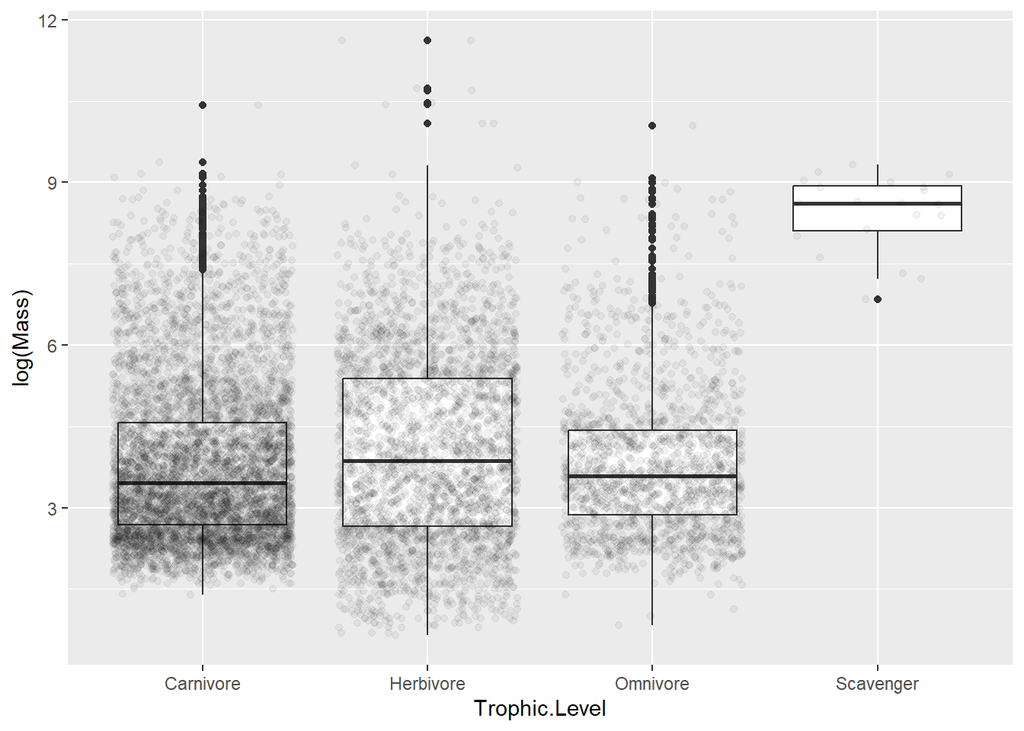

```r
(p1)
```

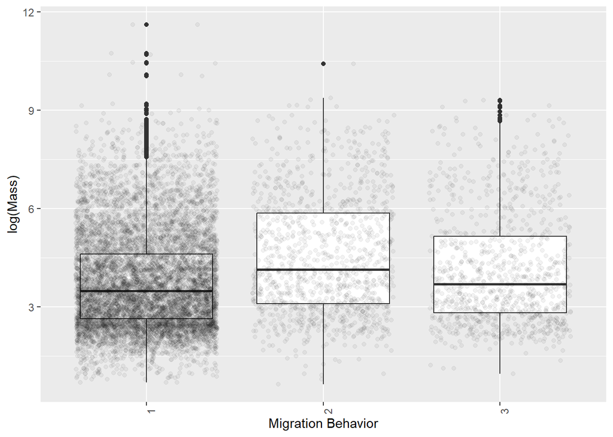

```r
#Dropping all species records where Migration is missing from the dataset
d3 <- d |> drop_na("Migration")

#Box plot of log(Mass) in relation to Migration behavior type
p2 <- ggplot(data = d3, aes(x = Migration, y = log(Mass))) +
  geom_boxplot(na.rm = TRUE) +
  geom_jitter(alpha = 0.05) +
  theme(axis.text.x = element_text(angle = 90)) + #Specifying axis labels
  ylab("log(Mass)") +
  xlab("Migration Behavior")
(p2)
```

### Step 2

#### Run linear models using the lm() function to look at the relationship between log(Mass) and Trophic.Level and between log(Mass) and Migration.

```r
#Linear model looking at relationship between log(Mass) and Trophic.Level
(lm1 <- lm((log(Mass)) ~ Trophic.Level, data = d2))
```

```
##
## Call:
## lm(formula = (log(Mass)) ~ Trophic.Level, data = d2)
##
## Coefficients:
##            (Intercept)  Trophic.LevelHerbivore   Trophic.LevelOmnivore
##                3.80834                 0.25639                 0.01422
## Trophic.LevelScavenger
##                4.63189
```

```r
(summary(lm1))
```

```
##
## Call:
## lm(formula = (log(Mass)) ~ Trophic.Level, data = d2)
##
## Residuals:
##     Min      1Q  Median      3Q     Max
## -3.4229 -1.1551 -0.3028  0.8982  7.5526
##
## Coefficients:
##                        Estimate Std. Error t value Pr(>|t|)
## (Intercept)             3.80834    0.01967 193.632  < 2e-16 ***
## Trophic.LevelHerbivore  0.25639    0.03406   7.528 5.54e-14 ***
## Trophic.LevelOmnivore   0.01422    0.04116   0.345     0.73
## Trophic.LevelScavenger  4.63189    0.34447  13.446  < 2e-16 ***
## ---
## Signif. codes:  0 '***' 0.001 '**' 0.01 '*' 0.05 '.' 0.1 ' ' 1
##
## Residual standard error: 1.538 on 11000 degrees of freedom
## Multiple R-squared:  0.02094,    Adjusted R-squared:  0.02067
## F-statistic: 78.42 on 3 and 11000 DF,  p-value: < 2.2e-16
```

```r
#Linear model looking at relationship between log(Mass) and Migration
(lm2 <- lm((log(Mass)) ~ Migration, data = d3))
```

```
##
## Call:
## lm(formula = (log(Mass)) ~ Migration, data = d3)
##
## Coefficients:
## (Intercept)   Migration2   Migration3
##      3.7746       0.7597       0.3765
```

```r
(summary(lm2))
```

```
##
## Call:
## lm(formula = (log(Mass)) ~ Migration, data = d3)
##
## Residuals:
##     Min      1Q  Median      3Q     Max
## -3.8924 -1.1769 -0.3088  0.9152  7.8427
##
## Coefficients:
##             Estimate Std. Error t value Pr(>|t|)
## (Intercept)  3.77457    0.01636 230.710  < 2e-16 ***
## Migration2   0.75971    0.04731  16.059  < 2e-16 ***
## Migration3   0.37647    0.05155   7.303 3.02e-13 ***
## ---
## Signif. codes:  0 '***' 0.001 '**' 0.01 '*' 0.05 '.' 0.1 ' ' 1
##
## Residual standard error: 1.535 on 10983 degrees of freedom
## Multiple R-squared:  0.02563,    Adjusted R-squared:  0.02546
## F-statistic: 144.5 on 2 and 10983 DF,  p-value: < 2.2e-16
```

Both linear models are significant. Log(Mass) is significantly associated with Trophic.Level, and log(Mass) is significantly associated with Migration category.

For the Migration model, **Migration category 1** is the **reference level**. **Migration category 2** and **Migration category 3** both differ significantly from Migration category 1.

```r
#Releveling and assessing differences among the remaining pair of Migration categories.

d4 <- d |>
  mutate(Migration = relevel(Migration, ref = "3"))

lm3<- lm(log(Mass) ~ Migration, data = d4)
(summary(lm3))
```

```
##
## Call:
## lm(formula = log(Mass) ~ Migration, data = d4)
##
## Residuals:
##     Min      1Q  Median      3Q     Max
## -3.8924 -1.1769 -0.3088  0.9152  7.8427
##
## Coefficients:
##             Estimate Std. Error t value Pr(>|t|)
## (Intercept)  4.15104    0.04889  84.909  < 2e-16 ***
## Migration1  -0.37647    0.05155  -7.303 3.02e-13 ***
## Migration2   0.38324    0.06603   5.804 6.67e-09 ***
## ---
## Signif. codes:  0 '***' 0.001 '**' 0.01 '*' 0.05 '.' 0.1 ' ' 1
##
## Residual standard error: 1.535 on 10983 degrees of freedom
##   (23 observations deleted due to missingness)
## Multiple R-squared:  0.02563,    Adjusted R-squared:  0.02546
## F-statistic: 144.5 on 2 and 10983 DF,  p-value: < 2.2e-16
```

After releveling, **Migration category 3** is the **reference level**. Migration category 2 also differs significantly from Migration category 3.

### Step 3

#### Conduct a post-hoc Tukey Honest Significant Differences test to also evaluate which Migration categories differ “significantly” from one another.

```r
#One-Factor ANOVA
maov1 <- aov((log(Mass)) ~ Migration, data = d3)

#post-hoc Tukey Honest Significant Differences test
(posthoc <- TukeyHSD(maov1, which = "Migration", conf.level = 0.95))
```

```
##   Tukey multiple comparisons of means
##     95% family-wise confidence level
##
## Fit: aov(formula = (log(Mass)) ~ Migration, data = d3)
##
## $Migration
##           diff        lwr        upr p adj
## 2-1  0.7597067  0.6488157  0.8705977     0
## 3-1  0.3764693  0.2556282  0.4973105     0
## 3-2 -0.3832374 -0.5380211 -0.2284536     0
```

Looking at the adjusted p-values, all three Migration categories significantly differ from each other.

### Step 4

#### Use a permutation approach to inference to generate a null distribution of F statistic values for the model of log(Mass) in relation to Trophic.Level and calculate a p value for your original F statistic.

```r
#Results for F statistic and p-value for Omnibus F test
(original.F <- aov(log(Mass) ~ Trophic.Level, data = d2) |>
  tidy() |>
  filter(term == "Trophic.Level"))
```

```
## # A tibble: 1 × 6
##   term             df sumsq meansq statistic  p.value
##   <chr>         <dbl> <dbl>  <dbl>     <dbl>    <dbl>
## 1 Trophic.Level     3  557.   186.      78.4 3.43e-50
```

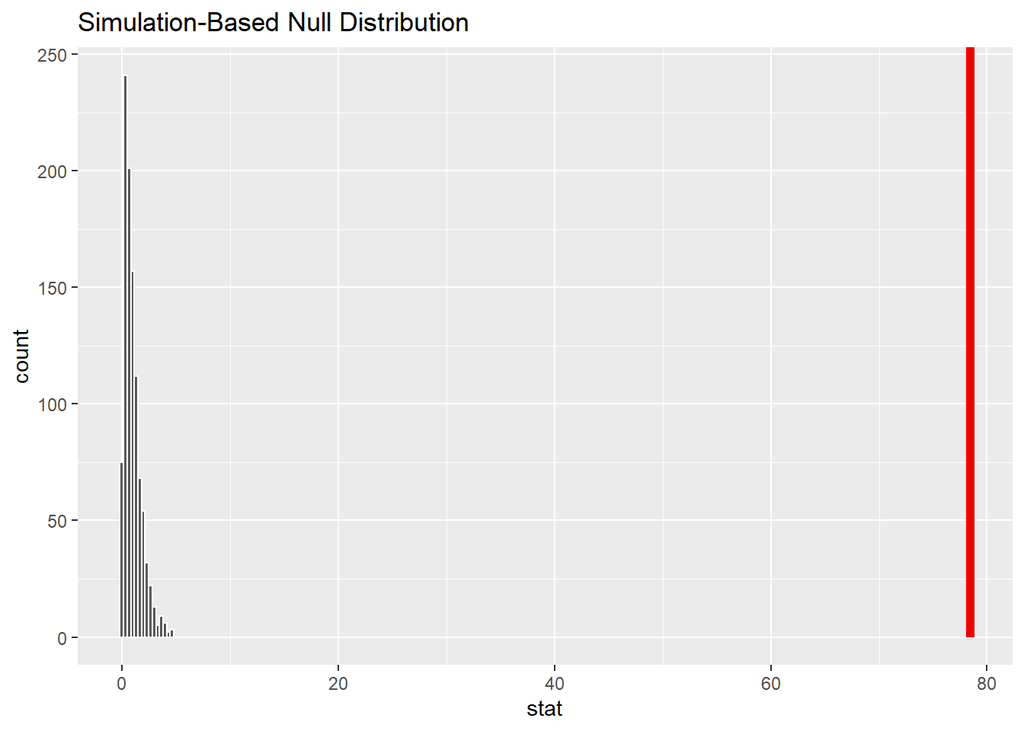

```r
#Creating new variable, logMass
d2 <- d2 |> mutate(logMass = log(Mass))

#Permutation approach to inference using {infer}
permuted.F <- d2 |>
  specify(logMass ~ Trophic.Level) |>
  hypothesize(null = "independence") |>
  generate(reps = 1000, type = "permute") |>
  calculate(stat = "F")

#Histogram
visualize(permuted.F) +
  shade_p_value(obs_stat = original.F$statistic, direction = "greater")
```

```r
#Calculating p-value for original F statistic
p.value <- permuted.F |> get_p_value(obs_stat = original.F$statistic, direction = "greater")
(original.F$p.value)
```

[output not shown]

```
## [1] 3.433649e-50
```

## Challenge 2: Data Wrangling, One and Two-Factor ANOVA

### Step 1

#### Create the following two new variables and add them to AVONET dataset: Relative beak length and Relative tarsus length.

```r
#Relative beak length, calculated as the residual of log(Beak.Length_Culmen) on log(Mass)
d$relBeak.Length <- resid(lm(formula = log(Beak.Length_Culmen) ~ log(Mass), data=d))

#Relative tarsus length, calculated as the residual of log(Tarsus.Length) on log(Mass)
d$relTarsus.Length <- resid(lm(formula = log(Tarsus.Length) ~ log(Mass), data=d))
```

### Step 2

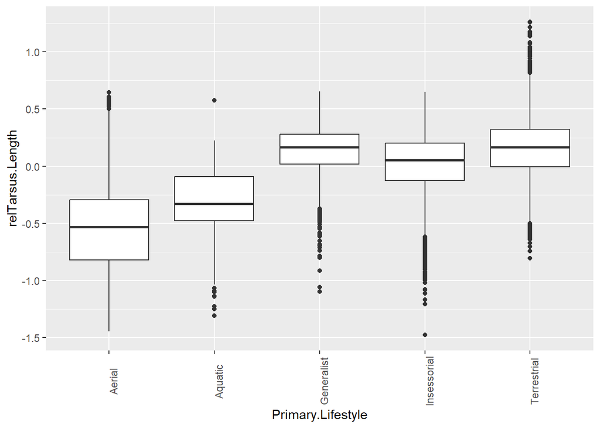

```r
#Boxplot for relative tarsus length in relation to Primary.Lifestyle
(p3 <- ggplot(data = d |> filter(!is.na(Primary.Lifestyle)), aes(x = Primary.Lifestyle, y = relTarsus.Length)) +
  geom_boxplot() +
   theme(axis.text.x = element_text(angle = 90)))
```

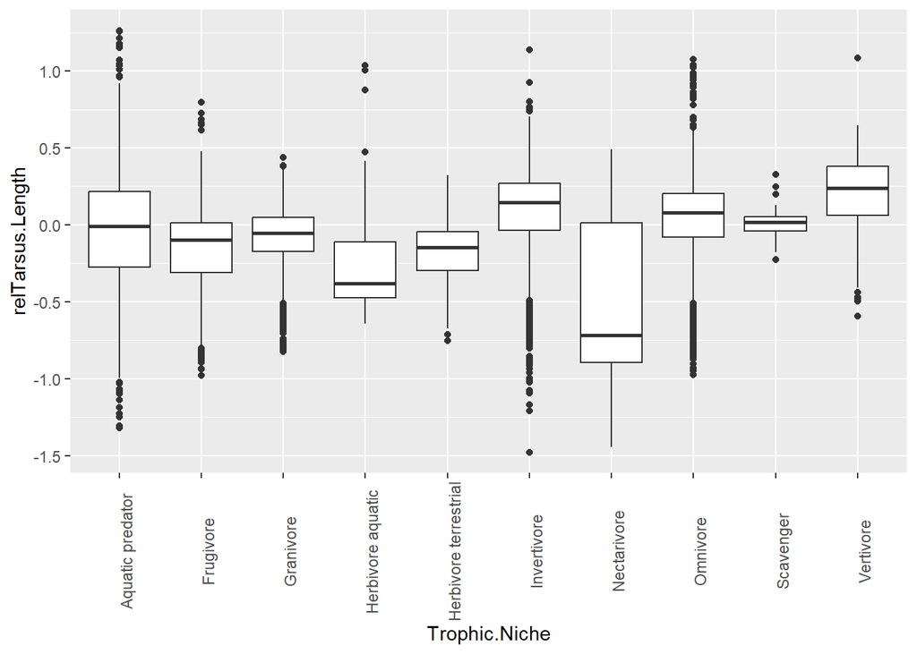

```r
#Boxplot for relative tarsus length in relation to Trophic.Niche
(p4 <- ggplot(data = d |> filter(!is.na(Trophic.Niche)), aes(x = Trophic.Niche, y = relTarsus.Length)) +
  geom_boxplot() +
   theme(axis.text.x = element_text(angle = 90)))
```

### Step 3

#### Run an ANOVA analyses to look at the association between geographic range size and the variable Migration.

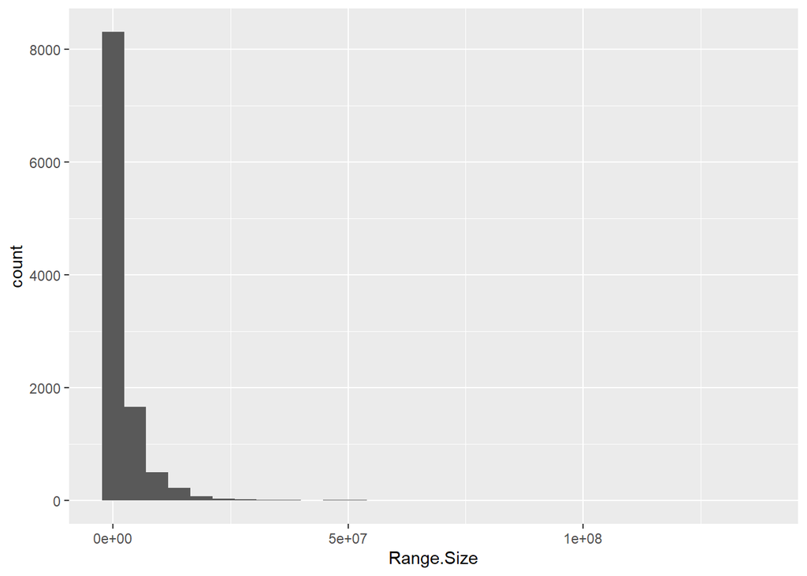

```r
#Looking at distribution of Range.Size
ggplot(data = d, aes(x = Range.Size)) +
    geom_histogram()
```

```r
#One-Factor ANOVA
d3 <- d3 |> mutate(logRange.Size = log(Range.Size))
lm4 <- lm(logRange.Size ~ Migration, data = d3)
(summary(lm4))
```

```
##
## Call:
## lm(formula = logRange.Size ~ Migration, data = d3)
##
## Residuals:
##      Min       1Q   Median       3Q      Max
## -14.5710  -1.4521   0.4357   1.9763   5.9271
##
## Coefficients:
##             Estimate Std. Error t value Pr(>|t|)
## (Intercept) 12.03381    0.02974  404.62   <2e-16 ***
## Migration2   1.78469    0.08606   20.74   <2e-16 ***
## Migration3   2.51702    0.09380   26.83   <2e-16 ***
## ---
## Signif. codes:  0 '***' 0.001 '**' 0.01 '*' 0.05 '.' 0.1 ' ' 1
##
## Residual standard error: 2.785 on 10934 degrees of freedom
##   (49 observations deleted due to missingness)
## Multiple R-squared:  0.0869, Adjusted R-squared:  0.08674
## F-statistic: 520.3 on 2 and 10934 DF,  p-value: < 2.2e-16
```

Based on the global model, range size is significantly associated with Migration category. Looking at the R-squared value, 8.7% of the total variance in log(Range.Size) can be explained by Migration in this model.

The **reference level** is **Migration category 1**. **Migration category 2** and **Migration category 3** both differ significantly from Migration category 1.

```r
#Releveling and assessing differences among the remaining pair of Migration categories.

d5 <- d |>
  mutate(Migration = relevel(Migration, ref = "3"))

lm5 <- lm(log(Mass) ~ Migration, data = d5)
(summary(lm5))
```

```
##
## Call:
## lm(formula = log(Mass) ~ Migration, data = d5)
##
## Residuals:
##     Min      1Q  Median      3Q     Max
## -3.8924 -1.1769 -0.3088  0.9152  7.8427
##
## Coefficients:
##             Estimate Std. Error t value Pr(>|t|)
## (Intercept)  4.15104    0.04889  84.909  < 2e-16 ***
## Migration1  -0.37647    0.05155  -7.303 3.02e-13 ***
## Migration2   0.38324    0.06603   5.804 6.67e-09 ***
## ---
## Signif. codes:  0 '***' 0.001 '**' 0.01 '*' 0.05 '.' 0.1 ' ' 1
##
## Residual standard error: 1.535 on 10983 degrees of freedom
##   (23 observations deleted due to missingness)
## Multiple R-squared:  0.02563,    Adjusted R-squared:  0.02546
## F-statistic: 144.5 on 2 and 10983 DF,  p-value: < 2.2e-16
```

```r
#ANOVA
maov2 <- aov(log(Range.Size) ~ Migration, data = d3)

#post-hoc Tukey Honest Significant Differences test
(posthoc <- TukeyHSD(maov2, which = "Migration", conf.level = 0.95))
```

```
##   Tukey multiple comparisons of means
##     95% family-wise confidence level
##
## Fit: aov(formula = log(Range.Size) ~ Migration, data = d3)
##
## $Migration
##          diff      lwr      upr p adj
## 2-1 1.7846901 1.582952 1.986428     0
## 3-1 2.5170168 2.297150 2.736883     0
## 3-2 0.7323266 0.450689 1.013964     0
```

Looking at the adjusted p-values, all three Migration categories significantly differ from each other.

### Step 4

```r
#Winnowing data to just consider birds from the Order Passeriformes
d_pass <- d |> filter(Order1 == "Passeriformes")

#One-Factor ANOVA looking at association between relative beak length and Primary.Lifestyle
maov3 <- aov(relBeak.Length ~ Primary.Lifestyle, data = d_pass)
(summary(maov3))
```

```
##                     Df Sum Sq Mean Sq F value Pr(>F)
## Primary.Lifestyle    3   18.2   6.067   130.2 <2e-16 ***
## Residuals         6610  307.9   0.047
## ---
## Signif. codes:  0 '***' 0.001 '**' 0.01 '*' 0.05 '.' 0.1 ' ' 1
```

```r
#Linear model looking at association between relative beak length and Primary.Lifestyle
lm6 <- lm(relBeak.Length ~ Primary.Lifestyle, data = d_pass)
(summary(lm6))
```

```
##
## Call:
## lm(formula = relBeak.Length ~ Primary.Lifestyle, data = d_pass)
##
## Residuals:
##     Min      1Q  Median      3Q     Max
## -0.6314 -0.1380 -0.0172  0.1118  1.2241
##
## Coefficients:
##                              Estimate Std. Error t value Pr(>|t|)
## (Intercept)                  -0.34950    0.02158  -16.19   <2e-16 ***
## Primary.LifestyleGeneralist   0.27926    0.02306   12.11   <2e-16 ***
## Primary.LifestyleInsessorial  0.35342    0.02181   16.20   <2e-16 ***
## Primary.LifestyleTerrestrial  0.27924    0.02249   12.42   <2e-16 ***
## ---
## Signif. codes:  0 '***' 0.001 '**' 0.01 '*' 0.05 '.' 0.1 ' ' 1
##
## Residual standard error: 0.2158 on 6610 degrees of freedom
## Multiple R-squared:  0.05581,    Adjusted R-squared:  0.05538
## F-statistic: 130.2 on 3 and 6610 DF,  p-value: < 2.2e-16
```

Based on the global model, relative beak length is significantly associated with Primary.Lifestyle. 5.6% of the variance in relative beak length can be explained by Primary.Lifesyle.

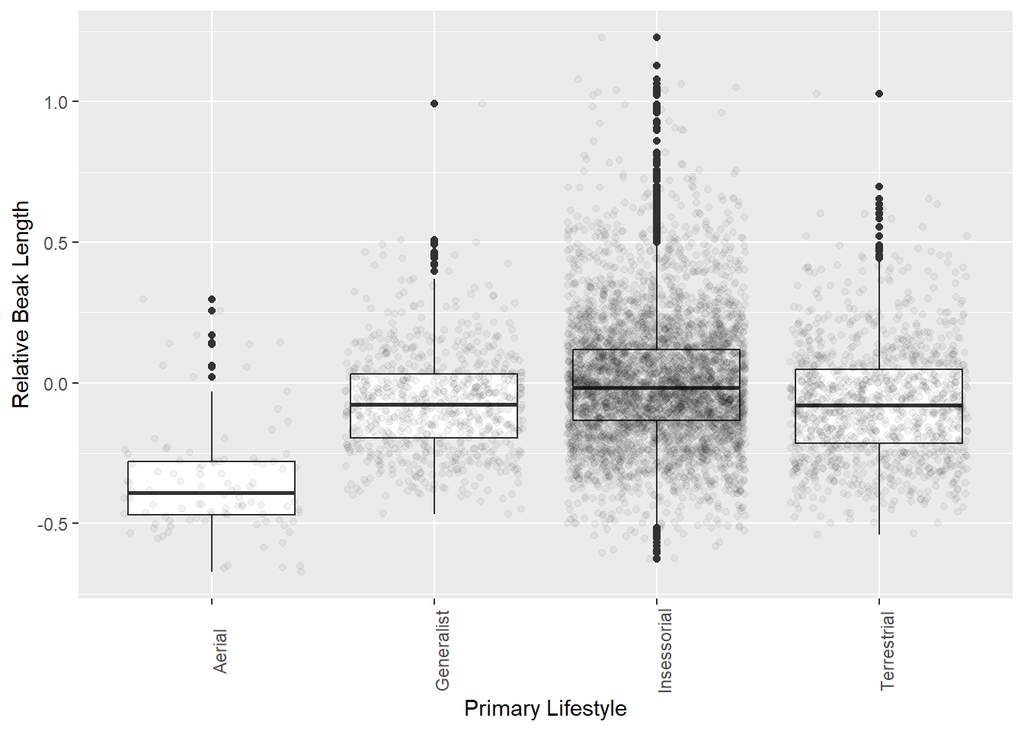

```r
#Boxplot looking at association between relative beak length and Primary.Lifestyle

p5 <- ggplot(d_pass |> filter(!is.na(Primary.Lifestyle)), aes(x = Primary.Lifestyle, y = relBeak.Length)) +
  geom_boxplot(na.rm = TRUE) +
  geom_jitter(alpha = 0.05) +
  theme(axis.text.x = element_text(angle = 90)) + #Specifying axis labels
  ylab("Relative Beak Length") +
  xlab("Primary Lifestyle")
(p5)
```

```r
#One-Factor ANOVA looking at association between relative beak length and Trophic.Level
maov4 <- aov(relBeak.Length ~ Trophic.Level, data = d_pass)
(summary(maov4))
```

```
##                 Df Sum Sq Mean Sq F value Pr(>F)
## Trophic.Level    2  16.31   8.154     174 <2e-16 ***
## Residuals     6611 309.81   0.047
## ---
## Signif. codes:  0 '***' 0.001 '**' 0.01 '*' 0.05 '.' 0.1 ' ' 1
```

```r
#Linear model looking at association between relative beak length and Trophic.Level
lm7 <- lm(relBeak.Length ~ Trophic.Level, data = d_pass)
(summary(lm7))
```

```
##
## Call:
## lm(formula = relBeak.Length ~ Trophic.Level, data = d_pass)
##
## Residuals:
##      Min       1Q   Median       3Q      Max
## -0.67045 -0.13692 -0.02063  0.11129  1.23116
##
## Coefficients:
##                         Estimate Std. Error t value Pr(>|t|)
## (Intercept)            -0.003170   0.003501  -0.906  0.36518
## Trophic.LevelHerbivore -0.118713   0.006956 -17.066  < 2e-16 ***
## Trophic.LevelOmnivore   0.017902   0.006606   2.710  0.00675 **
## ---
## Signif. codes:  0 '***' 0.001 '**' 0.01 '*' 0.05 '.' 0.1 ' ' 1
##
## Residual standard error: 0.2165 on 6611 degrees of freedom
## Multiple R-squared:  0.05001,    Adjusted R-squared:  0.04972
## F-statistic:   174 on 2 and 6611 DF,  p-value: < 2.2e-16
```

Based on the global model, relative beak length is significantly associated with Trophic.Level. 5.0% of the variance in relative beak length can be explained by Trophic.Level.

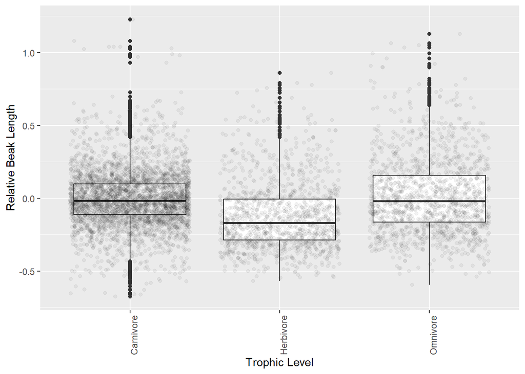

```r
#Boxplot looking at association between relative beak length and Trophic.Level

p6 <- ggplot(d_pass |> filter(!is.na(Trophic.Level)), aes(x = Trophic.Level, y = relBeak.Length)) +
  geom_boxplot(na.rm = TRUE) +
  geom_jitter(alpha = 0.05) +
  theme(axis.text.x = element_text(angle = 90)) + #Specifying axis labels
  ylab("Relative Beak Length") +
  xlab("Trophic Level")
(p6)
```

### Step 5

#### Run a two-factor model to look at the association between relative beak length and both Primary.Lifestyle and Trophic.Level among the passeriforms

```r
#Two-Factor ANOVA without interaction term

maov5 <- aov(relBeak.Length ~ Trophic.Level + Primary.Lifestyle, data = d_pass)
(summary(maov5))
```

```
##                     Df Sum Sq Mean Sq F value Pr(>F)
## Trophic.Level        2  16.31   8.154   185.7 <2e-16 ***
## Primary.Lifestyle    3  19.57   6.523   148.5 <2e-16 ***
## Residuals         6608 290.24   0.044
## ---
## Signif. codes:  0 '***' 0.001 '**' 0.01 '*' 0.05 '.' 0.1 ' ' 1
```

Holding Primary.Lifestyle constant, Trophic.Level has an impact on relative beak length. Holding Trophic.Level constant, Primary.Lifestyle has an impact on relative beak length.

### Step 6

#### Run an additional two-way model with the same dataset and predictors, but adding the possibility of an interaction term.

```r
#Two-Factor ANOVA with interaction term
maov6 <- aov(relBeak.Length ~ Trophic.Level + Primary.Lifestyle + Trophic.Level:Primary.Lifestyle, data = d_pass)
(summary(maov6))
```

```
##                                   Df Sum Sq Mean Sq F value Pr(>F)
## Trophic.Level                      2  16.31   8.154  191.08 <2e-16 ***
## Primary.Lifestyle                  3  19.57   6.523  152.84 <2e-16 ***
## Trophic.Level:Primary.Lifestyle    4   8.41   2.102   49.26 <2e-16 ***
## Residuals                       6604 281.83   0.043
## ---
## Signif. codes:  0 '***' 0.001 '**' 0.01 '*' 0.05 '.' 0.1 ' ' 1
```

Based on the model output, I would conclude that the interaction between Trophic.Level and Primary.Lifestyle also is a significant predictor in variation in relative beak length.

### Step 7

#### Use the interaction.plot() function to visualize the interaction between Primary.Lifestyle and Trophic.Level

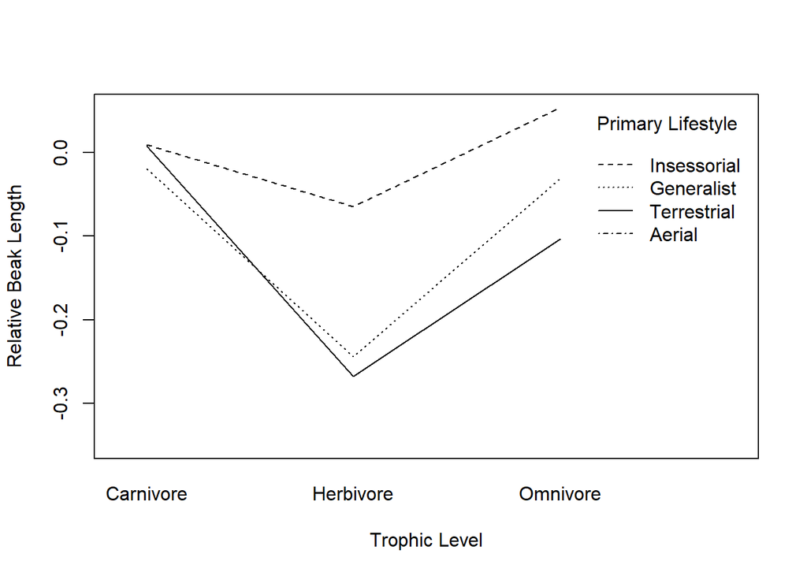

```r
p8 <- interaction.plot(x.factor = d_pass$Trophic.Level,
                 xlab = "Trophic Level",
                 trace.factor = d_pass$Primary.Lifestyle,
                 trace.label = "Primary Lifestyle",
                 response = d_pass$relBeak.Length,
                 ylab = "Relative Beak Length")
```

```r
(p8)
```

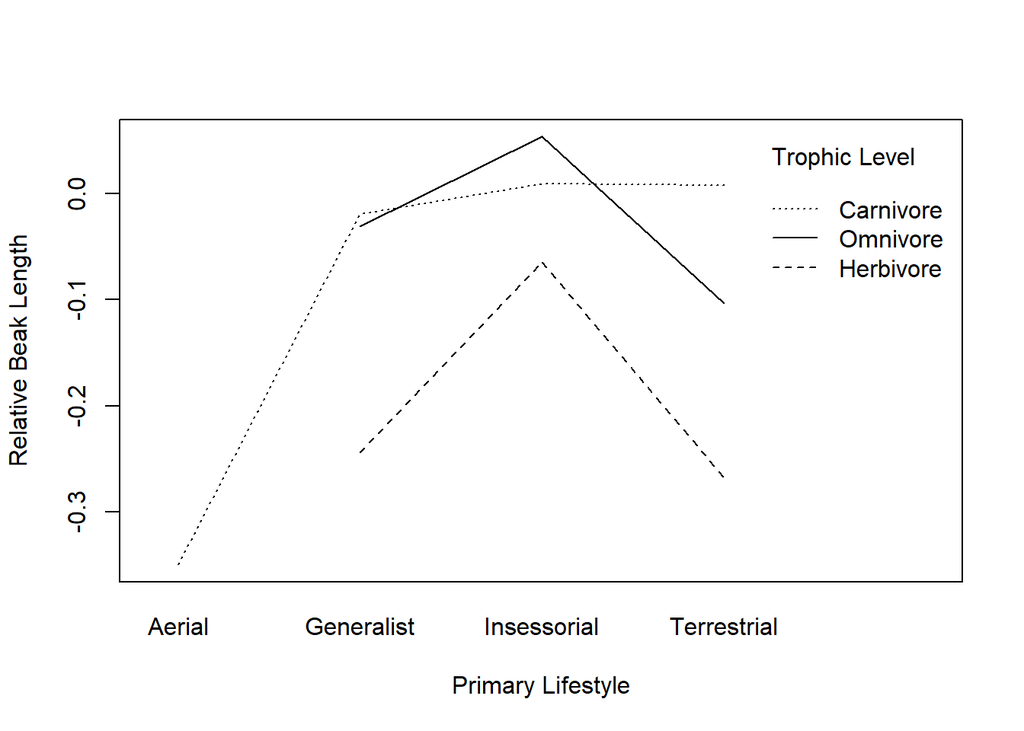

```r
#Flipping my axes
p9 <- interaction.plot(x.factor = d_pass$Primary.Lifestyle,
                 xlab = "Primary Lifestyle",
                 trace.factor = d_pass$Trophic.Level,
                 trace.label = "Trophic Level",
                 response = d_pass$relBeak.Length,
                 ylab = "Relative Beak Length")
```

```r
(p9)
```